# USMR Lecture 2

The groundwork

Milan Valášek

# Introductory Stuff

## Briefly about me

- PhD Psychology, University of Edinburgh
- Psychometrician, Royal College of Surgeons of Edinburgh (stats, coding in `R`)
- Teaching post-doc in statistics in `R`, University of Edinburgh
- Senior teaching co-ordinator, University of Edinburgh

## Office hours

- Not compulsory but I’d encourage you to make use of them
- Flexible - send me a meeting request individually or as a group at https://doodle.com/mvalasek
- Questions can be
  - About the course
  - Conceptual
  - Coding issues
  - About slides
  - About lab exercises
  - Generally about stats

## Arrest this man, he talks in maths

- There will be numbers, there will be maths
- Maths (and logic) is the language of computers, statistics, science, and – it seems – the universe
- We will focus on developing a conceptual understanding and intuition
- We won’t discuss anything that is beyond your capability to understand
- It won’t be a walk in the park though so do put in the hours

## If you find yourself struggling

- Go back to where you last felt on top of things and take it from there
- **Come** talk to us
- **Ask** questions during the lectures
- Make use of the discussion forum on LEARN
- Take a deep breath, go for a walk, **you’ll be fine**!

# Overview of Weeks 2-5

## Lectures

- Conceptual basis for statistical analysis
  - Logic & sets, probability, independence, sampling, variables, descriptive statistics
  - Functions, basic data visualisation, sampling distribution, Central Limit Theorem
  - Hypotheses, probability distributions, significance testing
- Basic statistical tests
  - *z*-test, *t*-test, *$\chi$<sup>2</sup>* test, correlation, *F*-test

## Labs

- Fundamentals of `R`
  - Commands, objects, functions, data structures
  - Working with data: indexing, subsetting, transformations
- Exploring and visualising data
  - Descriptive statistics, plots
- Basic statistical tests in `R`

## Before we start

- All clear regarding research questions/design and measurement?

## Today

- Logic, sets, probability
  - Probability theory is the basis for all of statistics
  - Sits on a foundation of logic and set theory
  - Not the focus of this course but we need to talk about these topics a little
- Sampling & independence
- Variables
  - Descriptive statistics

# That’s logic, innit!

## Logic

- Informally, a discipline concerned with truth value of statements, relationships between objects, and inference based on them
- There are several systems of logic but we will only discuss [Boolean](https://en.wikipedia.org/wiki/Boolean_algebra) logic, in which a statement can be exclusively either `TRUE` (1) or `FALSE` (0)
- The basis of all maths and computing
- If you want to be able to code, you need to understand at least the basics
- *Note.* The following is a **strictly informal** treatment of logic. Instead of using formal notation, I will use the `R` notation

## Logic – truth value (1)

- Statement is a meaningful utterance about objects in the world and their relationships.
  - *e.g.,* *“Today is Wednesday.”* or *“Two is qual to five.”*
- Based on the nature of the relationships and the premises, a statement can either be `TRUE` (1) or `FALSE` (0)
- Premises don’t have to be *“true”* in the sense of corresponding to our experience of reality. We can assess the truth value of a statement even if it’s based on outlandish premises

## Logic – truth value (2)

1. *All rivers are laughter*
2. *All laughter takes a chance*

   Therefore
3. *All rivers take a chance*
- The conclusion is a valid inference based on the premises and so is `TRUE`, even though it sounds like New Age “wisdom”

```r
# R-ish for "equals" or "is" is ==, not = !
weekdays(Sys.Date()) == "Wednesday"
[1] TRUE

2 == 5
[1] FALSE

# object orange has the value "apple" (premise)
orange <- "apple"
orange == "apple"
[1] TRUE
```

## Logic – Boolean operators (1)

- Logical operators express relationships between objects (equality, `==`, is an example)
- There are lots of them but we will focus on four *Boolean operators*:
- NOT (`!`)
- AND (`&` in `R`)
- OR (`|`)
- exclusive OR, XOR (the `xor()` function in `R`)

## Logic – Boolean operators (2)

- They are quite intuitive except for the OR/XOR distinction
- A statement linking two objects statements with OR is `TRUE` if **either** of the partial statement is `TRUE` **or both of them** are `TRUE`
- XOR returns `TRUE` **if and only if one of the statements** is `TRUE`

## Logic in `R`

- *Note.* `%in%` is a membership operator in `R` – `a %in% A` means “element `a` is in the object `A`”; Its result is `TRUE`/`FLASE`

```r
A <- 1:5 # A contains numbers from 1 to 5
B <- c(-1, 3, 5, 7) # B contains numbers -1, 3, 5, and 7

1 %in% A
[1] TRUE

1 %in% B
[1] FALSE
```

- If the thing to the left of `%in%` is an object containing several elements, the results will be one logical value per element (*i.e.,* `%in%` is *vectorised*)

```r
A %in% B
[1] FALSE FALSE  TRUE FALSE  TRUE
```

## Logic – NOT (`!`)

- The simplest operator
- Negates the subsequent statement, *i.e.,* turns `TRUE` to `FALSE` and *vice versa*
- if `A == B` is `FALSE`, `!(A == B)` or `A != B` will be `TRUE`

```r
a <- TRUE
!a
[1] FALSE

!(1 %in% A)
[1] FALSE
```

## Logic – AND (`&`)

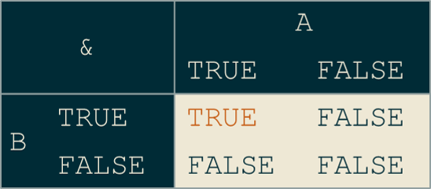

```r
1 %in% A & 5 %in% B # 1 is in A AND 5 is in B
[1] TRUE
```

`!(A & B)` is equivalent to `xor(A, B) | (!A & !B)`

## Logic – OR (`|`)

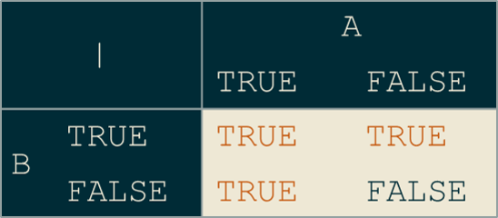

```r
-30 %in% A | 5 %in% B # first FALSE, second TRUE
[1] TRUE
```

`!(A | B)` is equivalent to `(!A & !B)`

## Logic – XOR (`xor()`)

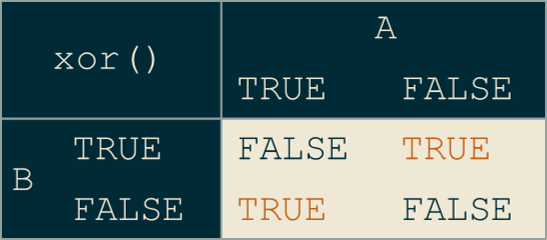

```r
xor(5 %in% A, -1 %in% B) # both TRUE
[1] FALSE
```

`!xor(A, B)` is equivalent to `(A & B) | (!A & !B)`

# Get set . . .

## Sets (1)

- Set theory sits on a foundation of logic and forms the basis for all maths
- Set is a well-defined group of objects/elements: we can tell which elements belong to which set
- You can think of our two groups `A` and `B` from before as sets

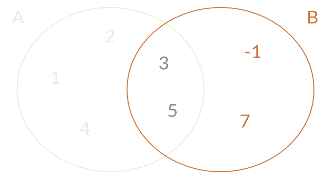

## Sets (2)

- *Subset* of set `A` is a set that **only contains elements that are also in** `A`
- Sets `C` and `D` are equal if and only if `C` is a subset of `D` AND `D` is a subset of `C`
- Subset of a set `A` that is *not equal* to `A` is called **proper subset**

## Set operations

- You can think of elements of a set as statements about the elements’ membership of a given set
  - 1 is in `A`
  - 3 is in `A`
  - 3 is in `B`…
- Just like you can perform logical operations on statements, you can perform set operations on sets
- Logical and set operations are analogous of each other
- *Note.* I’ll keep using the notation introduced above instead of standard [set notation](https://www.cs.sfu.ca/~ggbaker/zju/math/set-oper.html)

## Set intersection

- Intersection of sets `A` and `B` consists of elements that are present in **both** of these sets
- Analogous to `A & B`

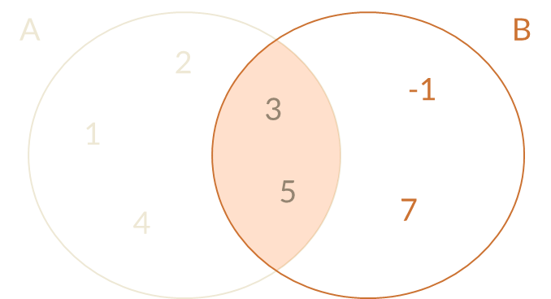

- Intersection of two sets that do not share elements is an *empty set* – ∅

## Set union

- Union of sets `A` and `B` consists of all elements that are present in **either** of these sets
- Analogous to `A | B`

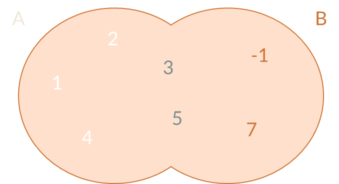

## Set difference

- Difference between sets `B` and `A` consists of all elements that are in `B` **but not in** `A`
- Analogous to `B & !A`

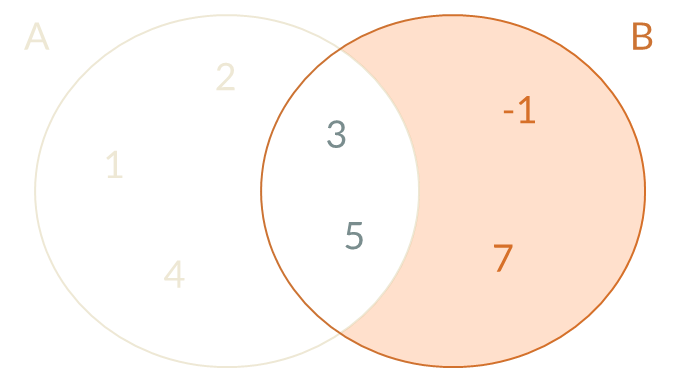

- *Question:* What is the difference of `C` and `D` such that `C` is equal to `D`?

## Set complement

- Complement of set `A` consists of all elements that are **in the universal set but not in** `A`
- Analogous to `!A`

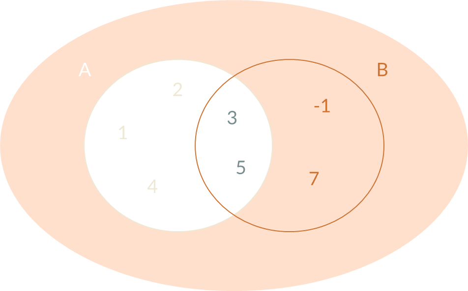

## Union of differences

- Not an operation in its own right but a combination of union and difference
- *Question:* Which logical operation is analogous to the union of `A` – `B` and `B` – `A`?

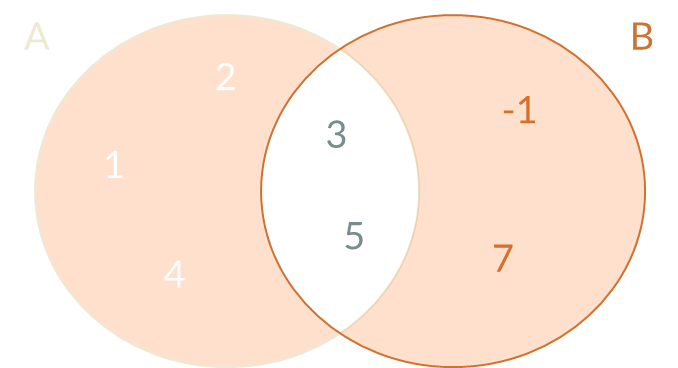

- `xor(A, B)` or `(A & !B) | (B & !A)`

# Probability matters (p < .001)

## Probability

- System of attributing chance to events
- Based on a foundation of logic and set theory
- Informs all of statistics
- Main approaches: [frequentist](https://en.wikipedia.org/wiki/Frequentist_probability) and [Bayesian](https://en.wikipedia.org/wiki/Bayesian_probability)
- We focus on the frequentist approach but be aware that Bayesian statistics has been gaining a lot of traction in recent years

## It’s a tricky business

- Unlike things we’ve talked about, probability is not intuitive
- We didn’t evolve to solve probabilistic problems analytically but to adopt heuristics
- The whole field started as a result of this counter-intuitive nature
  - One Antoine Gombaud, Chevalier de Méré noticed that when he bet on rolling **at least 1 double-six in 24 rolls of two dice**, he lost more often than when he bet on rolling **at least 1 six in 4 rolls of a single die** and was puzzled by it and challenged mathematicians to explain why
  - Blaise Pascal and Pierre de Fermat took up the challenge and, between themselves, laid the groundwork of modern probability theory

## Two goats and a car

- Another great historical example is the [Monty Hall problem](https://en.wikipedia.org/wiki/Monty_Hall_problem)
- Originally posed and solved in the 70s ([Selvin, 1975](https://www.jstor.org/stable/2683689)), it gained prominence in 1990, when it appeared in [Marilyn vos Savant](https://en.wikipedia.org/wiki/Marilyn_vos_Savant)’s column in Parade magazine
- The correct answer provoked a massive outcry ([transcript](http://marilynvossavant.com/game-show-problem/))
- The problem:

> Suppose you’re on a game show, and you’re given the choice of three doors. Behind one door is a car, behind the others, goats. You pick a door, say #1, and the host, who knows what’s behind the doors, opens another door, say #3, which has a goat. He says to you, *“Do you want to pick door #2?”* Is it to your advantage to switch your choice of doors?

## Definition

If there are *$a$* ways in which *$X$* can occur and *$b$* ways in which *$X$* can fail to occur, then the probability of *$X$* occurring is *$P(X) = a/(a+b)$*

## Jargon

- Let’s say we’re flipping a fair coin 10 times
- **Outcome** is the possible result; either heads (H) or tails (T)
- **Event** is a set of outcomes, *e.g.,* H H T H T T H H T H
- **Simple event** is a single unit of an event
- **Experiemnt** is the process generating simple events and producing outcome; flipping a coin
- **Sample space** is the set of all possible outcomes; all combinations of Hs and Ts of size 10

## The wolrd is a set

- You can conceptualise the whole world as a set
- Every single point in this set is a simple event that can possibly occur
- Somewhere in this set is a tiny sample space of outcomes of a 3 coin toss experiment

## Basic calculation

- Given definition above, since there are 3 ways we can get exactly one T and 5 ways we can get some other number of Ts, the probability of getting exactly one T if we flip a fair coin three times is *P(A) = 3 / (3 + 5)*

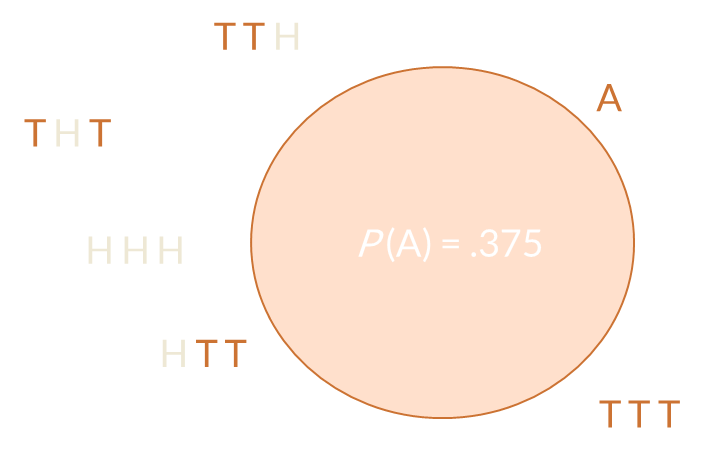

## Basic calculation

- Similarly, there is only one way of getting HHT (simple event *a*) when flipping a fair coin three times – and therefore seven ways this can fail to occur – so the probability of this happening is *P(a) = 1 / 8*

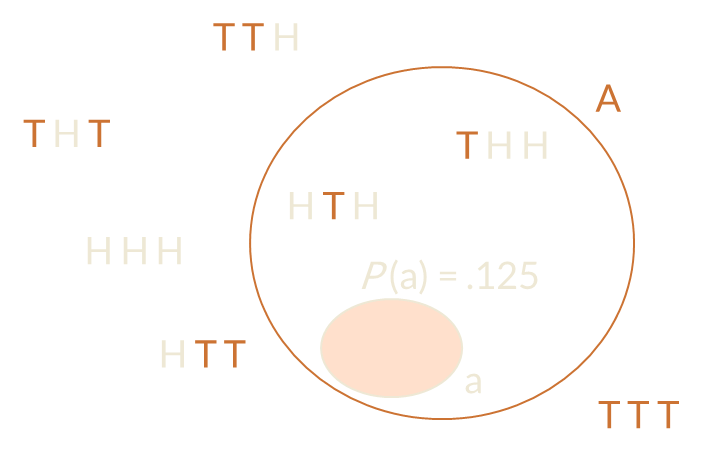

## Basic calculation

- OK, your turn, what is the probability of a subset of *A* that does not include *a*?
- *P(A & !a) = P(A) − P(a)*
- *P(A & !a) = .375 − .125 = .250*

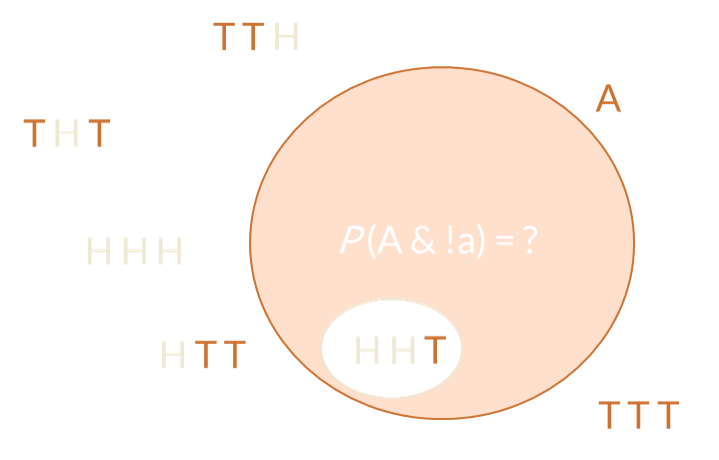

## Conditional probability

- Conditional probability *P(A|B)* is the probability of *A* occurring **given that B occurred**
- Here, it’s the probability of getting exactly 1 T in 3 flips of a fair coin **given** H on the first flip
- *Note.* ‘|’ is conditional probability, not the ‘OR’ operation

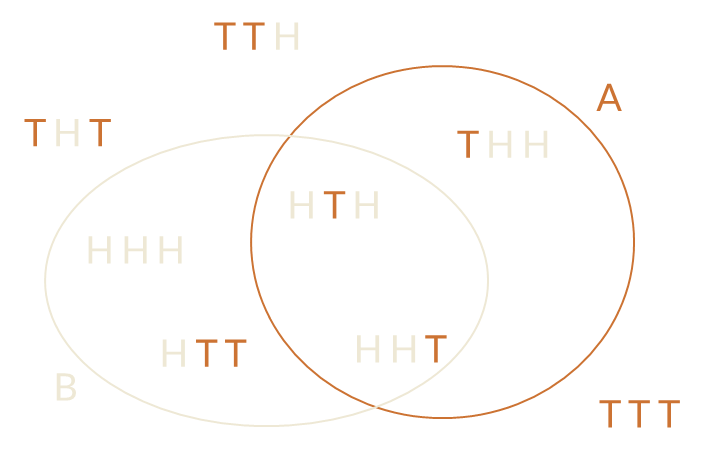

## Conditional probability

- To calculate *P(A|B)*, we need to know the probability of *A*, the probability of *B*, and the probability of *B given A*
- *$P(A|B) = \frac{P(B|A)\times P(A)}{P(B)}$*
- *$P(A|B) = \frac{2/3\times 3/8}{1/2}$*

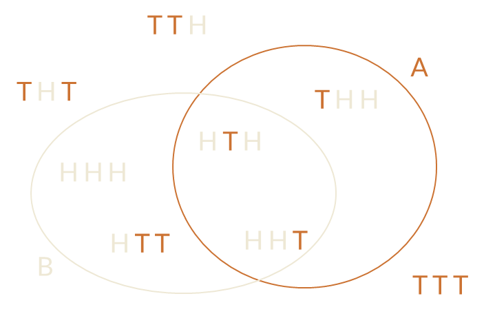

## Conditional probability

- To calculate *P(A|B)*, we need to know the probability of *A*, the probability of *B*, and the probability of *B given A*
- *$P(A|B) = \frac{P(B|A)\times P(A)}{P(B)}$*
- *$P(A|B) = \frac{2/3\times 3/8}{1/2}$*

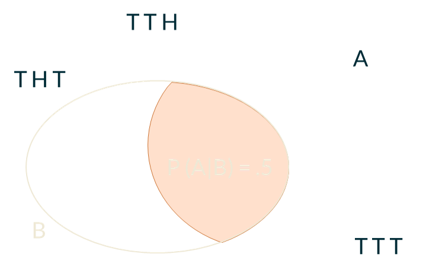

## Independence

- In probability theory, two events are said to be *independent* if the occurrence of one does not influence the probability of the other
- We saw that *P(A)* = .375 but *P(A|B)* = .5
- Likewise *P(B)* = .5 but *P(B|A)* = .667
- That means that *A* and *B* are dependent events
- Example of independent events would be getting H on first flip and getting T on second

## Joint probability

- If *A* and *B* are two distinct events, joint probability of *A* and *B* is the probability that *A* will occur NAD *B* will occur
- For **independent** events, *P(A & B) = P(A) × P(B)*
- For **dependent** events, *P(A & B) = P(A) × P(B|A)*

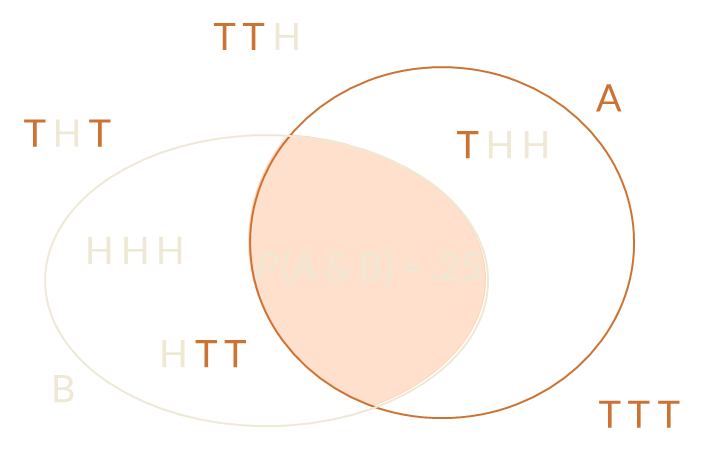

## Probability of union

- This is the probability of *A* occurring OR *B* occurring.
- But we need to be careful not to count their intersection twice!
- *P(A OR B) = P(A) + P(B) − P(A & B)*

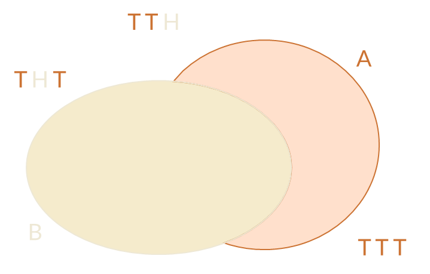

## Probability of union

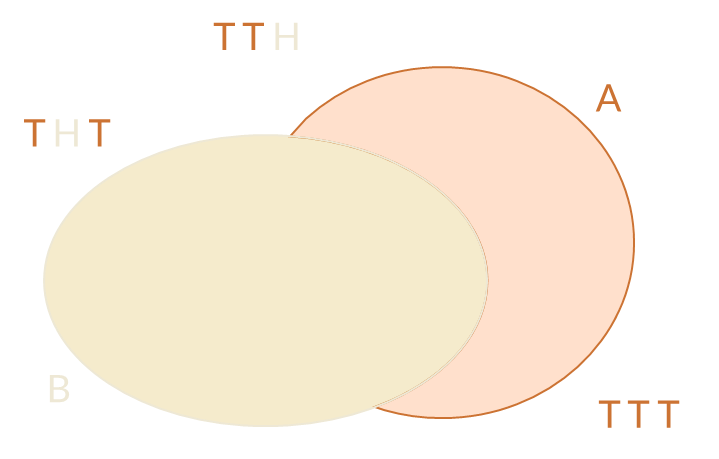

## Probability of union

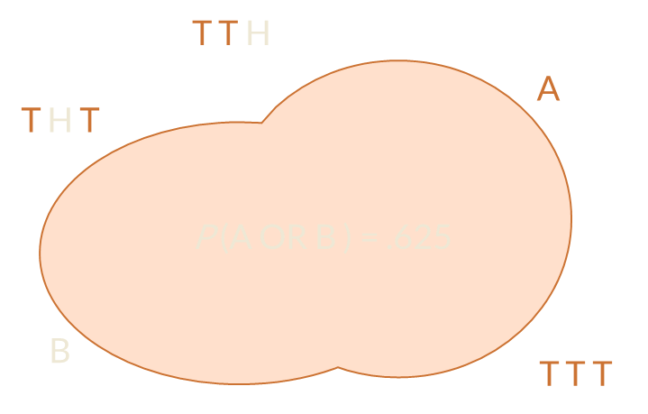

## Take-home message

- Probability builds on set theory builds on logic
- Basic logical and set operations are analogous
  - NOT : set complement
  - AND : set intersection
  - OR : set union
  - XOR : union of differences
- Logic behind probability calculations
- What we mean when we say events are (in)dependent
- How conditional probability expresses the influence one event has on another

# Take 10

# **And that’s all for today!** See you in the labs :)